# RuPaul_Group_Proj

2023-02-28

### Database: RuPaul’s Drag Race

### Members: Tamsen Dean, Ndemoh Sesay, and Samone Watkins

## Introduction

### Background Research:

RuPaul’s Drag Race premiered on LogoTv in 2009 and both produced and hosted by RuPaul a famous drag queen (queen of drag). Each season, 9-16 queens come to compete for some sort of prize ranging from cash to a lifetime supply of cosmetics. Each episode captures one week of prizes and a new celebrity judge. Each week features a mini-challenge at the beginning of the episode, main challenge judged by the judges, and a lipsync battle between the bottom two queens whose winner is determined by RuPaul herself. Mini-challenges consist of a smaller challenge such as a “read-off” which is similar to a roast. The mini-challenges are judged by only RuPaul and the winner receives immunity in the next week’s challenge. Main challenges consist of makeovers, singing challenges, and sewing challenges and are judged by the panel of judges. The main challenge highlights the winner of the challenge who receives immunity in the next week’s challenge, and the queens that will be competing in the lipsync battle. The loser of the lipsync battle gets eliminated. Drag Race has had 15 seasons so far, not including 6 spin-off series and international adaptations.

### Project Objective:

Through our exploration of the data set, we will be able to gain insight on the subconscious biases that the show has, both informing the viewer - allowing them to have a greater understanding of the media that they consume and informing the show-runners- allowing them to analyze their production’s biases potentially altering the show for greater equality should that be a concern.

### Research questions:

1. Can we predict the winner of RuPaul’s Drag Race using existing data and if so, how early can we do it?
2. Does the age of the queen matter in the winners?

### Data Description:

Our data is in the form of three dataframes. The first is ‘rpdr_contep’ which stands for: RuPaul’s Drag Race Episode-Contestant Data it the contestant-level overview of the data and has 11 variables including season (vector of numerical variables), rank(vector of numerical variables), contestant(vector of categorical variables), and episode number(vector of numerical variables). The second table is ‘rpdr_contestants’ which stands for: RuPaul’s Drag Race Contestant Data which are contestant-level data for RuPaul’s Drag Race for all available seasons this includes season, contestant, age, dob, and hometown. The third dataframe is ‘rpdr_ep’ which stands for: RuPaul’s Drag Race Episode Data and includes episode-level data for RuPaul’s Drag Race for all available seasons. The dataframe has 22 variables including season, episode, airdate, numqueens, and lipsyncsong. An in-depth description of all variables can be found in the documentation: https://cran.r-project.org/web/packages/dragracer/dragracer.pdf.

$rpdr contep Variables$

| Variable Name | Description | Data set | Variable Type |
| --- | --- | --- | --- |
| season | a character vector for the season | rpdr contep | numerical |
| rank | a numeric vector for the final rank of the contestant | rpdr contep | numerical |
| contestant | a character vector for the contestant’s name | rpdr contep | categorical |
| missc | a dummy variable indicating if the contestant was Miss Congeniality | rpdr contep | numerical |
| episode | a numeric vector for the episode number | rpdr contep | numerical |
| outcome | a character vector for the outcome for the queen after the main challenge | rpdr contep | Numerical |
| eliminated | a character vector (0,1) for if the queen was eliminated/removed from the competition after the episode | rpdr contep | Numerical |
| participant | a character vector (0,1) for if the queen was a participant in the show | rpdr contep | Numerical |
| minichalw | a character vector (0,1) if the queen won a mini-challenge that episode. NOTE: this is a work in progress. For now, I encourage getting the mini-challenge data from one of the other data sets. | rpdr contep | Numerical |
| finale | a numeric vector for if the episode was the finale | rpdr contep | Numerical |
| penultimate | a numeric vector for if the episode was the penultimate before the finale. Applicable to seasons 6, 7, and 8. | rpdr contep | Numerical |

$rpdr contestants Variables$

| Variable Name | Description | Data set | Variable Type |
| --- | --- | --- | --- |
| season | a character vector for the season | rpdr contestants | numerical |
| contestant | a character vector for contestant’s name, by season | rpdr contestants | categorical |
| age | a numeric vector for the respondent’s purported age as of filming | rpdr contestants | numerical |
| dob | a date vector for the contestant’s purported date of birth | rpdr contestants | Numerical |
| hometown | a character vector for hometown | rpdr contestants | categorical |

$rpdr ep Variables$

| Variable Name | Description | Data set | Variable Type |
| --- | --- | --- | --- |
| season | a character vector for the season | rpdr ep | numerical |
| episode | a numeric vector for the episode number | rpdr ep | numerical |
| airdate | a date for the episode air date | rpdr ep | numerical |
| special | Is the episode a special (e.g. a reunited or clip show) | rpdr ep | numerical |
| finale | Is the episode the finale | rpdr ep | numerical |
| nickname | Name of the episode | rpdr ep | categorical |
| runwaytheme | a character vector for runway theme, where applicable/available | rpdr ep | categorical |
| numqueens | a numeric vector for number of queens at the start of the episode | rpdr ep | numerical |
| minic | a character vector describing the mini-challenge | rpdr ep | numerical |
| minicw1 | a character vector for a mini-challenge winner | rpdr ep | numerical |
| minicw2 | a character vector for a second mini-challenge winner, where applicable | rpdr ep | numerical |
| minicw2 | a character vector for a second mini-challenge winner, where applicable | rpdr ep | numerical |
| minicw3 | a character vector for a third mini-challenge winner, where applicable | rpdr ep | numerical |
| minicw4 | a character vector for a fourth mini-challenge winner, where applicable | rpdr ep | numerical |
| bottom1 | a character vector for queen in the bottom 2 of that episode | rpdr ep | numerical |
| bottom2 | a character vector for queen in the bottom 2 of that episode | rpdr ep | numerical |
| bottom3 | a character vector for the third queen in the bottom of that episode. Thanks, Season 11. | rpdr ep | numerical |
| bottom4 | a character vector for the fourth queen in the bottom of that episode. Thanks, Season 11. | rpdr ep | numerical |
| bottom5 | a character vector for the fifth queen in the bottom of that episode. Thanks, Season 11. | rpdr ep | numerical |
| bottom6 | a character vector for the sixth queen in the bottom of that episode. Thanks, Season 11. | rpdr ep | numerical |
| bottom7 | a character vector for the seventh queen in the bottom of that episode. Thanks, Season 14. | rpdr ep | numerical |
| lipsyncartist | a character vector for the lip-sync artist | rpdr ep | numerical |
| lipsyncsong | a character vector for the lip-sync artist’s song | rpdr ep | numerical |
| eliminated1 | a character vector for the queen eliminated after the lip-sync | rpdr ep | numerical |
| eliminated2 | a character vector for the queen eliminated after the lip-sync, if there was a double-sashay that episode. | rpdr ep | numerical |

The data comes from https://github.com/svmiller/dragracer who is the author and owner of this data. There are both numerical and categorical variables in the dataset. There are a total of 38 variables across the three different data frames and was compiled using direct observation of the television show, compiling all available data.

```r
#combine all rpdr data sets
rpdr_combined <- rpdr_contep %>%
  full_join(rpdr_contestants, by = c("contestant" = "contestant",
                                     "season" = "season"))
```

## Data Exploration

```r
  rpdr_contestants %>%
  group_by(season) %>%
  summarize(mean_age = mean(age))
```

```
## # A tibble: 14 × 2
##    season mean_age
##    <chr>     <dbl>
##  1 S01        31
##  2 S02        27.6
##  3 S03        28.2
##  4 S04        29.2
##  5 S05        28
##  6 S06        29.3
##  7 S07        30.2
##  8 S08        29.8
##  9 S09        30.4
## 10 S10        28.3
## 11 S11        29.3
## 12 S12        28.4
## 13 S13        29.6
## 14 S14        26.4
```

```r
  glimpse(rpdr_contep)
```

```
## Rows: 2,320
## Columns: 11
## $ season      <chr> "S01", "S01", "S01", "S01", "S01", "S01", "S01", "S01", "S…
## $ rank        <dbl> 1, 2, 3, 4, 5, 6, 7, 8, 9, 1, 2, 3, 4, 5, 6, 7, 8, 9, 1, 2…
## $ missc       <chr> "0", "1", "0", "0", "0", "0", "0", "0", "0", "0", "1", "0"…
## $ contestant  <chr> "BeBe Zahara Benet", "Nina Flowers", "Rebecca Glasscock", …
## $ episode     <dbl> 1, 1, 1, 1, 1, 1, 1, 1, 1, 2, 2, 2, 2, 2, 2, 2, 2, 2, 3, 3…
## $ outcome     <chr> "SAFE", "WIN", "LOW", "SAFE", "HIGH", "SAFE", "BTM", "SAFE…
## $ eliminated  <chr> "0", "0", "0", "0", "0", "0", "0", "0", "1", "0", "0", "0"…
## $ participant <chr> "1", "1", "1", "1", "1", "1", "1", "1", "1", "1", "1", "1"…
## $ minichalw   <chr> "0", "0", "0", "0", "0", "0", "0", "0", "0", "0", "0", "0"…
## $ finale      <dbl> 0, 0, 0, 0, 0, 0, 0, 0, 0, 0, 0, 0, 0, 0, 0, 0, 0, 0, 0, 0…
## $ penultimate <dbl> 0, 0, 0, 0, 0, 0, 0, 0, 0, 0, 0, 0, 0, 0, 0, 0, 0, 0, 0, 0…
```

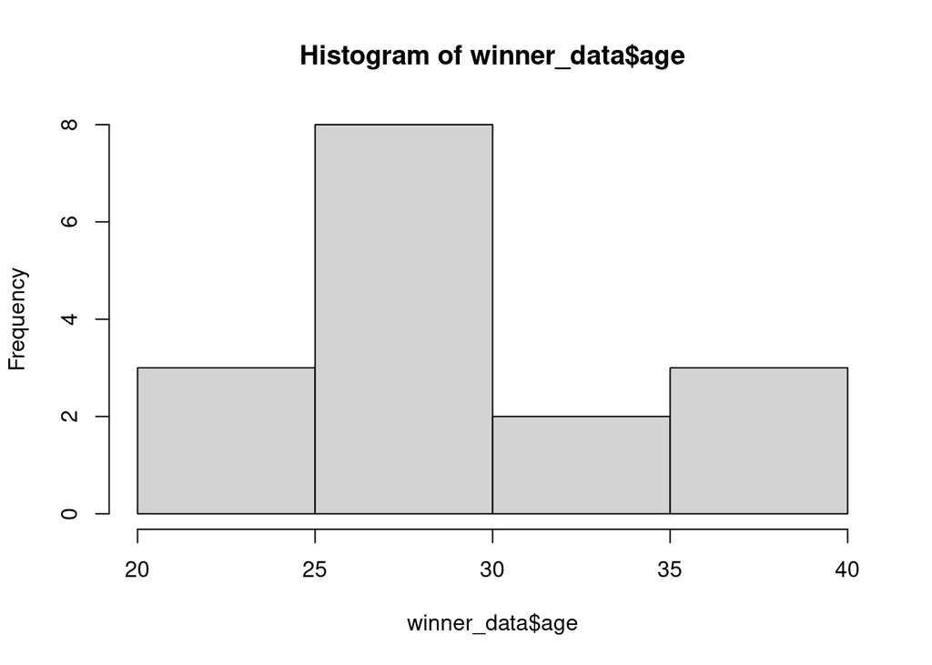

```r
  s1 <- filter(rpdr_contep, season=='S01')
  winners <- filter(rpdr_contep, episode=='8'& outcome=='WIN')
  winners1 <- winners$contestant
  winner_data <- filter(rpdr_contestants,is.element(contestant, winners1))
  firstlosers <- filter(rpdr_contep, episode=='1'& eliminated=='1')
  hist(winner_data$age)
```

## Statistical Methods

```r
library(dragracer)

head(rpdr_contestants)
```

```
## # A tibble: 6 × 5
##   season contestant          age dob        hometown
##   <chr>  <chr>             <dbl> <date>     <chr>
## 1 S01    BeBe Zahara Benet    28 1981-03-20 Minneapolis, Minnesota
## 2 S01    Nina Flowers         34 1974-02-22 Bayamón, Puerto Rico
## 3 S01    Rebecca Glasscock    26 1983-05-25 Fort Lauderdale, Florida
## 4 S01    Shannel              26 1979-07-03 Las Vegas, Nevada
## 5 S01    Ongina               26 1982-01-06 Los Angeles, California
## 6 S01    Jade                 32 1984-11-18 Chicago, Illinois
```

```r
head(rpdr_contep)
```

```
## # A tibble: 6 × 11
##   season  rank missc contestant   episode outcome elimi…¹ parti…² minic…³ finale
##   <chr>  <dbl> <chr> <chr>          <dbl> <chr>   <chr>   <chr>   <chr>    <dbl>
## 1 S01        1 0     BeBe Zahara…       1 SAFE    0       1       0            0
## 2 S01        2 1     Nina Flowers       1 WIN     0       1       0            0
## 3 S01        3 0     Rebecca Gla…       1 LOW     0       1       0            0
## 4 S01        4 0     Shannel            1 SAFE    0       1       0            0
## 5 S01        5 0     Ongina             1 HIGH    0       1       0            0
## 6 S01        6 0     Jade               1 SAFE    0       1       0            0
## # … with 1 more variable: penultimate <dbl>, and abbreviated variable names
## #   ¹eliminated, ²participant, ³minichalw
```

```r
#create a data frame with the contestants' ages, season, and final ranking
combined <- left_join(rpdr_contestants, rpdr_contep)
ranked <- combined %>%
          select(c("season", "contestant","rank", "age")) %>%
          distinct()

#create a data frame of the winners and contestants eliminated early
winners <- subset(ranked, rank == "1")
early_out <- subset(ranked, rank=="13"|rank =="14"|rank=="15")
head(winners)
```

```
## # A tibble: 6 × 4
##   season contestant         rank   age
##   <chr>  <chr>             <dbl> <dbl>
## 1 S01    BeBe Zahara Benet     1    28
## 2 S02    Tyra Sanchez          1    21
## 3 S03    Raja                  1    36
## 4 S04    Sharon Needles        1    29
## 5 S05    Jinkx Monsoon         1    24
## 6 S06    Bianca Del Rio        1    36
```

```r
head(early_out)
```

```
## # A tibble: 6 × 4
##   season contestant         rank   age
##   <chr>  <chr>             <dbl> <dbl>
## 1 S03    Venus D-Lite         13    26
## 2 S04    Alisa Summers        13    23
## 3 S05    Serena Cha Cha       13    21
## 4 S05    Penny Tration        14    39
## 5 S06    Magnolia Crawford    13    27
## 6 S06    Kelly Mantle         13    37
```

```r
stats <- tapply(ranked$age, ranked$season, summary)

#show summary statistics through season 6
head(stats, 6)
```

```
## $S01
##    Min. 1st Qu.  Median    Mean 3rd Qu.    Max.
##      26      26      32      31      34      39
##
## $S02
##    Min. 1st Qu.  Median    Mean 3rd Qu.    Max.
##   21.00   25.00   27.00   27.58   29.25   37.00
##
## $S03
##    Min. 1st Qu.  Median    Mean 3rd Qu.    Max.
##   23.00   26.00   28.00   28.23   29.00   36.00
##
## $S04
##    Min. 1st Qu.  Median    Mean 3rd Qu.    Max.
##   21.00   25.00   29.00   29.15   32.00   40.00
##
## $S05
##    Min. 1st Qu.  Median    Mean 3rd Qu.    Max.
##   21.00   25.25   27.00   28.00   28.75   39.00
##
## $S06
##    Min. 1st Qu.  Median    Mean 3rd Qu.    Max.
##   22.00   24.00   26.50   29.29   34.75   41.00
```

## Visualisation

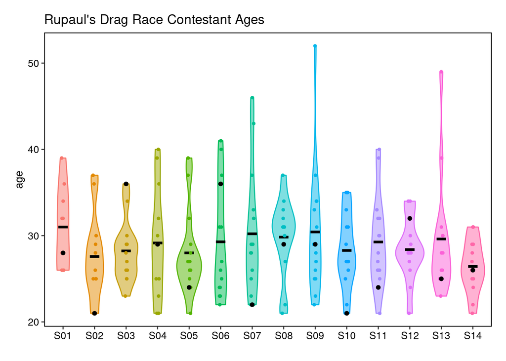

```r
# violin and scatterplots of all contestants' ages with crossbar of mean

age_all <- ggplot(ranked, aes(x = factor(season), y = age)) +
    geom_violin(aes(color = season, fill = season), alpha = 0.5) +
    stat_summary(fun = "mean",
                 geom = "crossbar",
                 width = 0.3) +
    geom_point(aes(color = season, fill = season),
                   position = position_jitterdodge(jitter.width = .1, dodge.width = 0),
                   shape=21, size = 1) +
    geom_point(data = winners, aes(x = factor(season))) +

# graph aesthetics

    labs(x = element_blank()) +
    ggtitle("Rupaul's Drag Race Contestant Ages") +
    theme(legend.position="none",
    strip.background=element_blank(),
    axis.text.x=element_text(size=10,color="black"),
    axis.text.y=element_text(size=10,color="black"),
    panel.background = element_blank(),
    panel.grid.major = element_blank(),
    panel.grid.minor = element_blank(),
    panel.border = element_rect(size= .75,fill = NA,color = "black"),
    plot.margin = unit(c(.5, 0.5, .5, .5), "cm"))
age_all
```

This visualization shows the distribution of ages of Drag Race contestants by season, including points for individual contestants’ ages, a crossbar showing the mean age of for that season, and a black dot showing the age of the winner. To perform a greater statistical analysis, we want to first see if there is variation between the means of the seasons. To do this we will perform an ANVOA test where our hypothesis are $H_0$: There is no variability between the mean ages of each season and $H_A$: There is at least one abnoral mean age in our dataset.

```r
#perform the anova test with age for each season
anova_one_way <- aov(age~season, data = rpdr_contestants)
summary(anova_one_way)
```

```
##              Df Sum Sq Mean Sq F value Pr(>F)
## season       13    251   19.28   0.626   0.83
## Residuals   170   5235   30.79
```

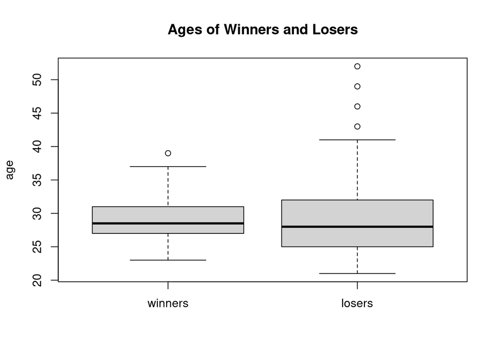

```r
#columns: name, season, win(y/n)

#separate the winner and loser data
winners <- winner_data[order(winner_data$age, decreasing = FALSE),]
losers <- subset(ranked, rank != "1")

#display boxplots of the information
boxplot(winners$age, losers$age, main = "Ages of Winners and Losers",
ylab = "age",names = c("winners", "losers"))
```

```r
#barplot(cyl_freq, horiz = TRUE)
t.test(winners$age, losers$age, alternative= "two.sided", paired = FALSE)
```

```
##
##  Welch Two Sample t-test
##
## data:  winners$age and losers$age
## t = 0.34579, df = 19.509, p-value = 0.7332
## alternative hypothesis: true difference in means is not equal to 0
## 95 percent confidence interval:
##  -2.103378  2.937698
## sample estimates:
## mean of x mean of y
##  29.50000  29.08284
```

## Conclusion

Anecdotally, younger contestants win more often than older contestants. Of the fourteen seasons of the show 11 of the seasons the winning Queen was younger than the mean age of contestants. There is no definitive reason that younger contestants win more often. However a few reasons why may be because younger contestants may be more attuned in the current fashion, music, and references throughout the competition. They are closer to the age of the target audience of the show. As seasons progress the younger queens have also grown up watching the show which may give them a better advantage as to how to do well and win on the show.

Our hypothesis was that younger contestants on Drag Race tend to win more on the show than older contestants. Despite the initial statistics and observations, our statistical test showed that age is not a signifying factor in the winners and losers. Therefore, our analysis does not support our hypothesis and we can conclude that the age of the drag queen is not a determining factor in their winnings.